# single-cell RNA-seq analysis

Dataset: Peripheral Blood Mononuclear Cells (PBMC) from 10X Genomics. There are 2,700 single cells that were sequenced on the Illumina NextSeq 500. Code is updated from Seurat package https://satijalab.org/seurat/

```r
library(dplyr)
library(Seurat)
library(patchwork)
```

Read10X function reads in the output of the [cellranger](https://support.10xgenomics.com/single-cell-gene-expression/software/pipelines/latest/what-is-cell-ranger) pipeline from 10X Genomics, returning a unique molecular identified (UMI) count matrix. The values in this matrix represent the number of molecules for each feature (i.e. gene; row) that are detected in each cell (column).

```r
pbmcdf.data <- Read10X("filtered_gene_bc_matrices/hg19/")
# Initialize the Seurat object with the raw (non-normalized data).
pbmcdf <- CreateSeuratObject(counts = pbmcdf.data, project = "pbmc3k", min.cells = 3, min.features = 200)
pbmcdf
```

```
FALSE An object of class Seurat
FALSE 13714 features across 2700 samples within 1 assay
FALSE Active assay: RNA (13714 features, 0 variable features)
```

Check the count matrix

```r
# check a few genes in the first 25 cells
pbmcdf.data[c("LYZ", "IGLL5", "GNLY", "FTL"), 1:25]
```

```
FALSE 4 x 25 sparse Matrix of class "dgCMatrix"
FALSE
FALSE LYZ    1  3 2 24  .  1 1 1 .  3 1 . 2 55 . 1 21 2  47 1  1 1 2 1  63
FALSE IGLL5  .  . .  .  .  . . . .  . . . .  . . .  . .   . .  . . . .   .
FALSE GNLY   .  . 1  .  3  . 5 . 1  . . . .  1 . .  . .   . 1  1 . 2 .   .
FALSE FTL   12 10 8 78 18 11 5 5 . 44 4 4 9 52 3 2 55 3 142 9 17 7 7 5 113
```

```r
dense.size <- object.size(as.matrix(pbmcdf.data))
cat('Dense size is:', dense.size)
```

```
FALSE Dense size is: 709591472
```

```r
sparse.size <- object.size(pbmcdf.data)
cat('Sparse size is:', sparse.size)
```

```
FALSE Sparse size is: 29905192
```

```r
cat('Ration of Dense/Sparse is:', dense.size/sparse.size)
```

```
FALSE Ration of Dense/Sparse is: 23.72804
```

Most values in an scRNA-seq matrix are 0, Seurat uses sparse-matrix to save memory and speed

# pre-processing

Includes the selection and filtration of cells based on QC metrics, data normalization and scaling, and the detection of highly variable features.

### QC and selecting cells for further analysis

```r
# Add columns to object metadata to stash QC stats
pbmcdf[["percent.mt"]] <- PercentageFeatureSet(pbmcdf, pattern = "^MT-")
# check QC metrics for the first a few cells
head(pbmcdf@meta.data, 10)
```

```
##                  orig.ident nCount_RNA nFeature_RNA percent.mt
## AAACATACAACCAC-1     pbmc3k       2419          779  3.0177759
## AAACATTGAGCTAC-1     pbmc3k       4903         1352  3.7935958
## AAACATTGATCAGC-1     pbmc3k       3147         1129  0.8897363
## AAACCGTGCTTCCG-1     pbmc3k       2639          960  1.7430845
## AAACCGTGTATGCG-1     pbmc3k        980          521  1.2244898
## AAACGCACTGGTAC-1     pbmc3k       2163          781  1.6643551
## AAACGCTGACCAGT-1     pbmc3k       2175          782  3.8160920
## AAACGCTGGTTCTT-1     pbmc3k       2260          790  3.0973451
## AAACGCTGTAGCCA-1     pbmc3k       1275          532  1.1764706
## AAACGCTGTTTCTG-1     pbmc3k       1103          550  2.9011786
```

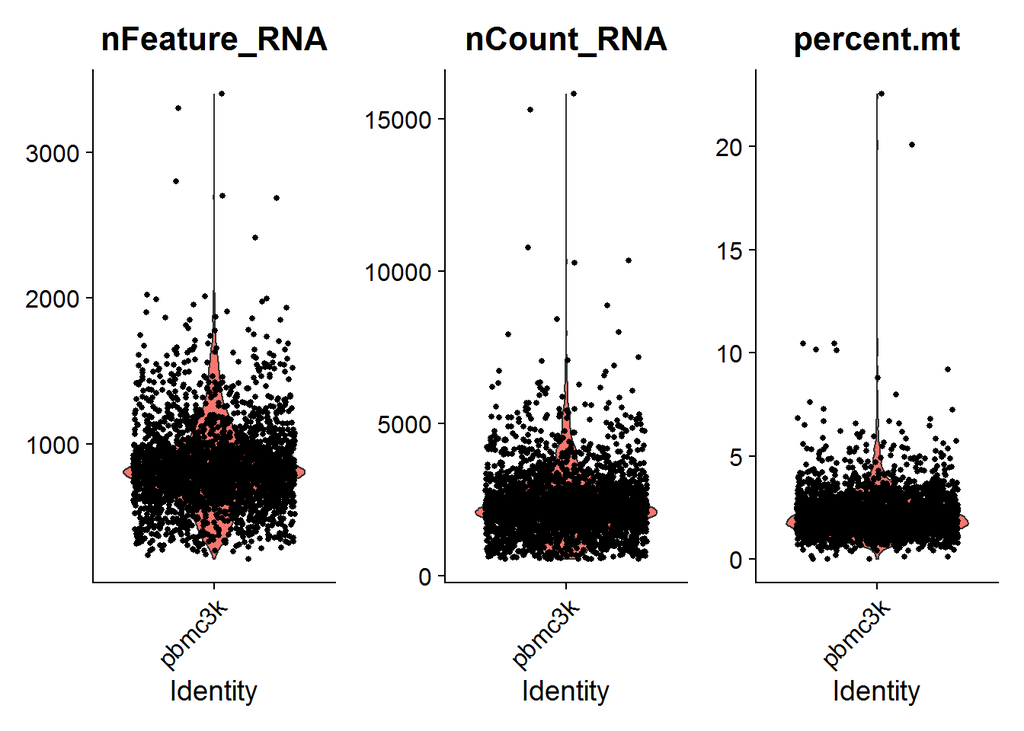

```r
# Visualize by violin plot
VlnPlot(pbmcdf, features = c("nFeature_RNA", "nCount_RNA", "percent.mt"), ncol = 3)
```

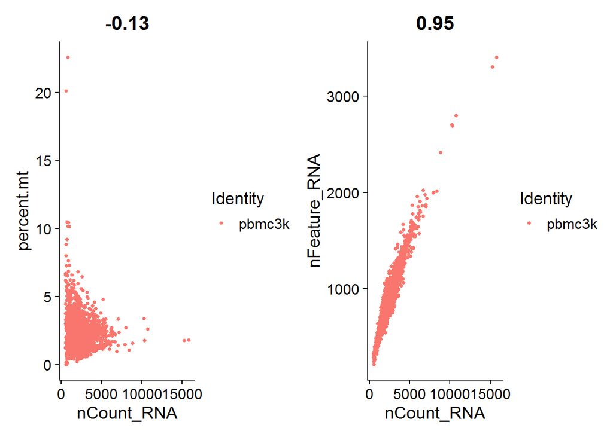

```r
# Scatter plot (FeatureScatter) for feature-feature relationships
plot1 <- FeatureScatter(pbmcdf, feature1 = "nCount_RNA", feature2 = "percent.mt")
plot2 <- FeatureScatter(pbmcdf, feature1 = "nCount_RNA", feature2 = "nFeature_RNA")
plot1 + plot2
```

### Data Normalization Subset data for further analysis. The “LogNormalize” method can normalizes the feature expression measurements for each cell by the total expression, multiplies this by a scale factor (10,000 by default), and log-transforms the result.

```r
#pbmcdf <- NormalizeData(pbmcdf, normalization.method = "LogNormalize", scale.factor = 10000)
# Default
pbmcdf <- NormalizeData(pbmcdf)
```

### Feature selection

Calculate a subset of features which are highly expressed in some cells, and lowly expressed in others

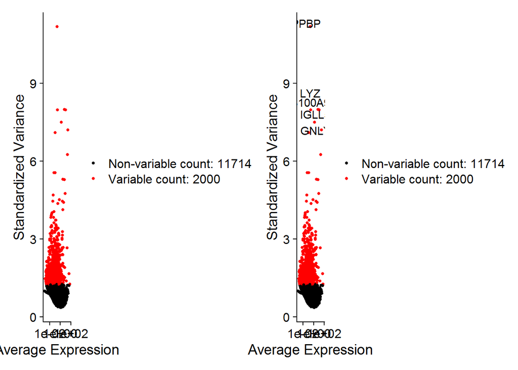

```r
pbmcdf <- FindVariableFeatures(pbmcdf, selection.method = "vst", nfeatures = 2000)
# top 5 most highly variable genes
top5 <- head(VariableFeatures(pbmcdf), 5)
# plot features
plot1 <- VariableFeaturePlot(pbmcdf)
plot2 <- LabelPoints(plot = plot1, points = top5, repel = TRUE)
plot1 + plot2
```

### Data scaling A linear transformation (‘scaling’) is processed prior to dimensional reduction techniques, PCA.

```r
pbmcdf <- ScaleData(pbmcdf)
# Remove unwanted sources of variation
pbmcdf <- ScaleData(pbmcdf, vars.to.regress = "percent.mt")
```

### Dimensional reduction_PCA

Linear dimensional reduction

```r
# PCA
pbmcdf <- RunPCA(pbmcdf, features = VariableFeatures(object = pbmcdf))
print(pbmcdf[["pca"]], dims = 1:10, nfeatures = 10)
```

```
## PC_ 1
## Positive:  MALAT1, LTB, IL32, CD2, ACAP1, STK17A, CTSW, CD247, CCL5, GIMAP5
## Negative:  CST3, TYROBP, LST1, AIF1, FTL, FCN1, LYZ, FTH1, S100A9, FCER1G
## PC_ 2
## Positive:  CD79A, MS4A1, TCL1A, HLA-DQA1, HLA-DRA, HLA-DQB1, LINC00926, CD79B, HLA-DRB1, CD74
## Negative:  NKG7, PRF1, GZMA, CST7, GZMB, FGFBP2, CTSW, GNLY, GZMH, SPON2
## PC_ 3
## Positive:  HLA-DQA1, CD79A, CD79B, HLA-DQB1, HLA-DPB1, CD74, HLA-DPA1, MS4A1, HLA-DRB1, HLA-DRB5
## Negative:  PPBP, PF4, SDPR, SPARC, GNG11, NRGN, GP9, RGS18, TUBB1, CLU
## PC_ 4
## Positive:  HLA-DQA1, CD79A, CD79B, HIST1H2AC, HLA-DQB1, MS4A1, PF4, CD74, SDPR, PPBP
## Negative:  VIM, S100A8, S100A6, S100A4, TMSB10, S100A9, IL32, GIMAP7, S100A10, LGALS2
## PC_ 5
## Positive:  GZMB, FGFBP2, NKG7, GNLY, CCL4, PRF1, CST7, SPON2, GZMA, XCL2
## Negative:  LTB, VIM, AQP3, PPA1, KIAA0101, MAL, CD2, IL32, TYMS, CYTIP
## PC_ 6
## Positive:  TYMS, KIAA0101, TK1, RRM2, MKI67, S100A8, MYBL2, ZWINT, BIRC5, GINS2
## Negative:  FCGR3A, CKB, MS4A7, IFITM2, HMOX1, MALAT1, VMO1, CTD-2006K23.1, ABI3, FAM110A
## PC_ 7
## Positive:  FCER1A, CLEC10A, SERPINF1, CD1C, CACNA2D3, ENHO, ID1, ANXA1, VIM, ALDH2
## Negative:  TYMS, ZWINT, RRM2, KIAA0101, TK1, FCGR3A, GINS2, BIRC5, MKI67, CKB
## PC_ 8
## Positive:  AKR1C3, IGFBP7, SPON2, GZMB, TMSB10, CLIC3, HAVCR2, S100B, GNLY, TRABD2A
## Negative:  GZMK, CCL5, KLRG1, LYAR, IL32, GZMA, S100A4, NKG7, CST7, JAKMIP1
## PC_ 9
## Positive:  RBP7, S100A12, S100A8, FOLR3, LINC00926, CD79A, LTB, S100A9, IFI35, CD79B
## Negative:  FCER1A, CLEC10A, ENHO, CD1C, SERPINF1, RP6-91H8.3, CACNA2D3, PPP2R3C, HLA-DQA2, FABP5
## PC_ 10
## Positive:  IGJ, MZB1, AQP3, S100A10, CRIP2, GAPDH, ACTB, AL928768.3, VIM, NOP58
## Negative:  IFIT1, GBP1, ISG15, MX1, IFI6, TNFSF10, UBE2L6, IFIT2, GIMAP4, MX2
```

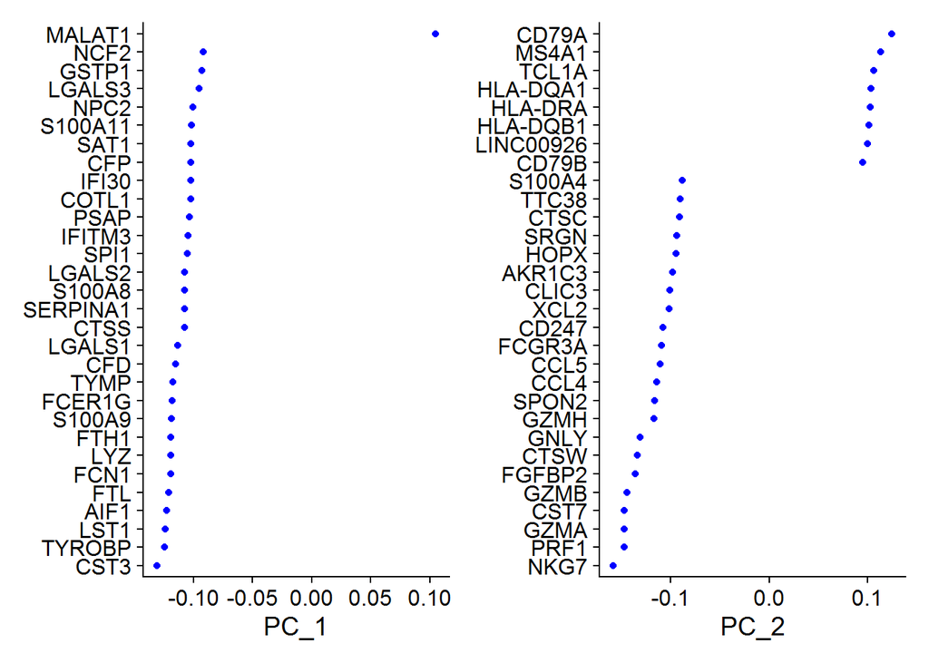

```r
# Visualization
VizDimLoadings(pbmcdf, dims = 1:2, reduction = "pca")
```

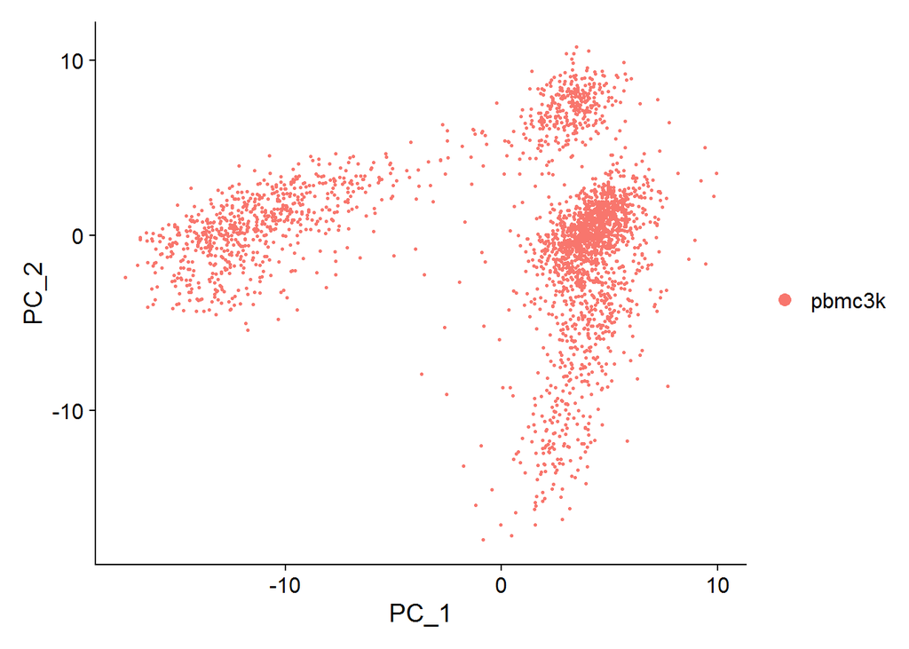

```r
DimPlot(pbmcdf, reduction = "pca")
```

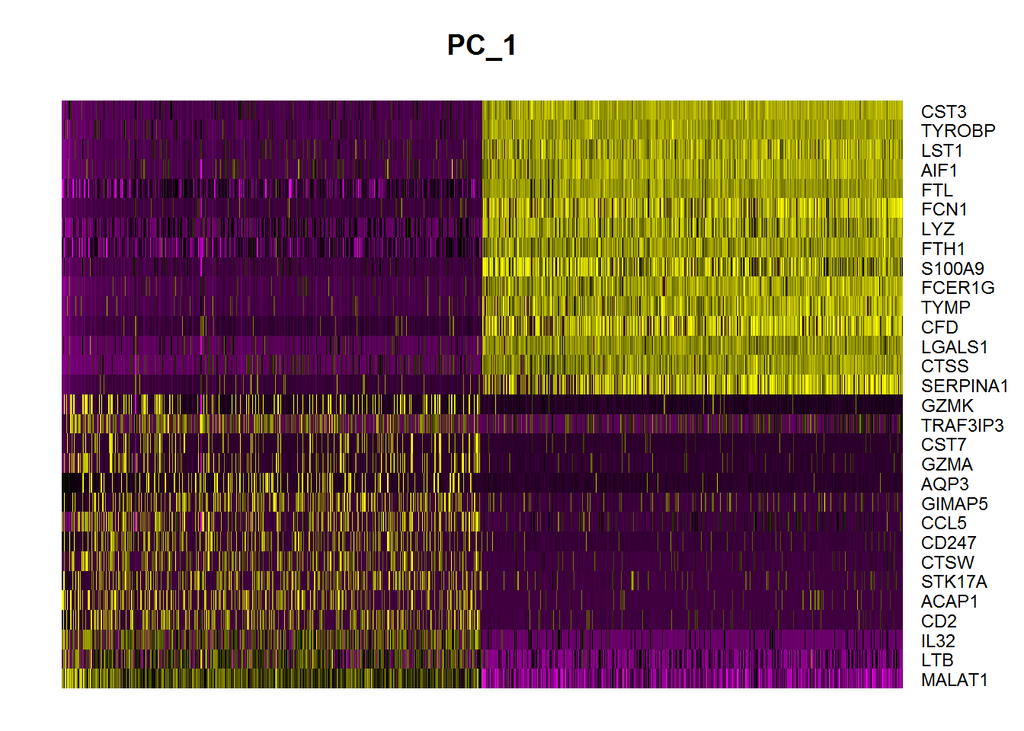

```r
DimHeatmap(pbmcdf, dims = 1, cells = 1000, balanced = TRUE)
```

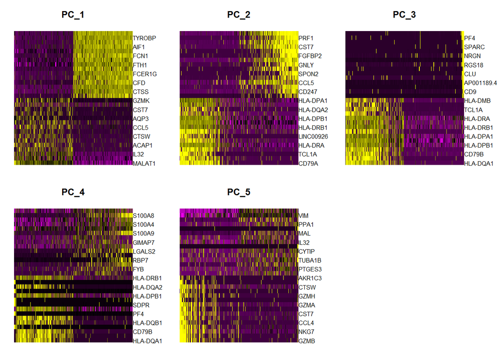

```r
DimHeatmap(pbmcdf, dims = 1:5, cells = 1000, balanced = TRUE)
```

### Select componenets Identify ‘significant’ PCs

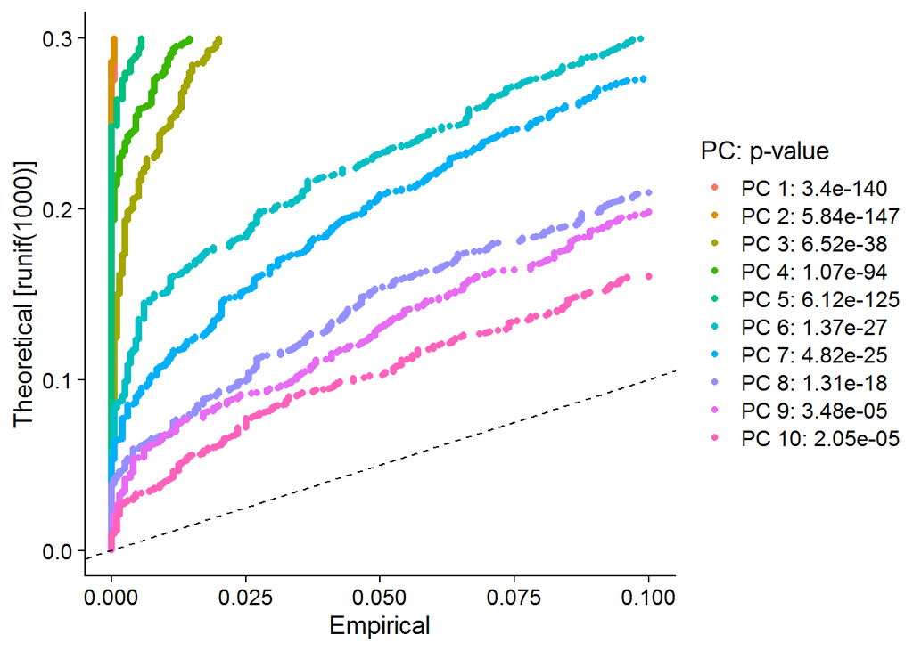

```r
pbmcdf <- JackStraw(pbmcdf, num.replicate = 100)
pbmcdf <- ScoreJackStraw(pbmcdf, dims = 1:10)
JackStrawPlot(pbmcdf, dims = 1:10)
```

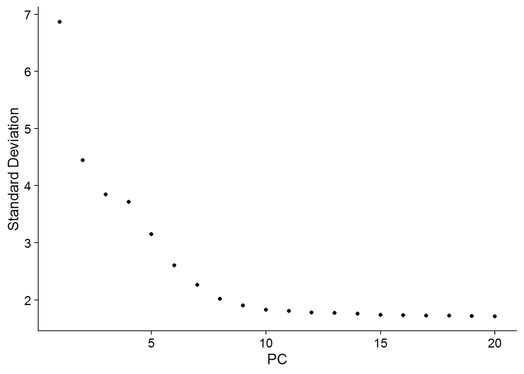

```r
ElbowPlot(pbmcdf)
```

### Cell Clustering

First construct a KNN graph based on the euclidean distance in PCA space, next apply modularity optimization techniques (Louvain algorithm (default) or SLM) to iteratively group cells together. Clusters can be found by Idents function.

```r
# Cluster
pbmcdf <- FindNeighbors(pbmcdf, dims = 1:10)
pbmcdf <- FindClusters(pbmcdf, resolution = 0.5)
```

```
## Modularity Optimizer version 1.3.0 by Ludo Waltman and Nees Jan van Eck
##
## Number of nodes: 2700
## Number of edges: 99220
##
## Running Louvain algorithm...
## Maximum modularity in 10 random starts: 0.8737
## Number of communities: 9
## Elapsed time: 0 seconds
```

```r
#cluster IDs of top 20 cells
head(Idents(pbmcdf), 20)
```

```
## AAACATACAACCAC-1 AAACATTGAGCTAC-1 AAACATTGATCAGC-1 AAACCGTGCTTCCG-1
##                1                3                1                5
## AAACCGTGTATGCG-1 AAACGCACTGGTAC-1 AAACGCTGACCAGT-1 AAACGCTGGTTCTT-1
##                6                1                4                4
## AAACGCTGTAGCCA-1 AAACGCTGTTTCTG-1 AAACTTGAAAAACG-1 AAACTTGATCCAGA-1
##                4                5                3                0
## AAAGAGACGAGATA-1 AAAGAGACGCGAGA-1 AAAGAGACGGACTT-1 AAAGAGACGGCATT-1
##                1                2                4                0
## AAAGATCTGGGCAA-1 AAAGCAGAAGCCAT-1 AAAGCAGATATCGG-1 AAAGCCTGTATGCG-1
##                2                4                2                1
## Levels: 0 1 2 3 4 5 6 7 8
```

### Dimensional reduction_UMAP

Non-linear dimensional reduction

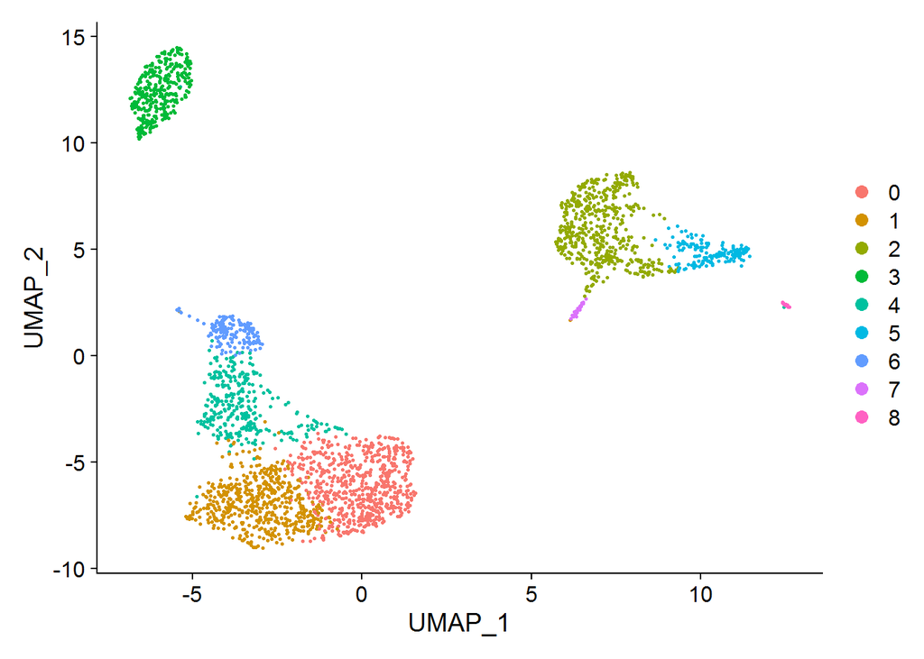

```r
pbmcdf <- RunUMAP(pbmcdf, dims = 1:10)
DimPlot(pbmcdf, reduction = "umap")
```

```r
saveRDS(pbmcdf, file = "output/pbmcdf_tutorial.rds")
```

### Differentially expressed features

```r
# find all markers of cluster 3
cluster3.markers <- FindMarkers(pbmcdf, ident.1 = 3, min.pct = 0.25)
head(cluster3.markers, n = 5)
```

```
##                   p_val avg_logFC pct.1 pct.2     p_val_adj
## CD79A      0.000000e+00  2.973221 0.934 0.043  0.000000e+00
## MS4A1      0.000000e+00  2.359796 0.860 0.052  0.000000e+00
## LINC00926 2.400862e-276  1.965097 0.562 0.009 3.292542e-272
## CD79B     2.983569e-275  2.401051 0.911 0.143 4.091667e-271
## TCL1A     8.485063e-274  2.482351 0.619 0.022 1.163642e-269
```

```r
# find all markers distinguishing cluster 4 from clusters 0 and 3
cluster4.markers <- FindMarkers(pbmcdf, ident.1 = 4, ident.2 = c(0, 3), min.pct = 0.25)
head(cluster4.markers, n = 5)
```

```
##              p_val avg_logFC pct.1 pct.2     p_val_adj
## NKG7 3.192010e-207  3.343647 0.951 0.105 4.377523e-203
## CCL5 4.098108e-181  2.562721 0.960 0.162 5.620146e-177
## CST7 4.838046e-179  2.316665 0.792 0.041 6.634896e-175
## GZMA 6.334881e-169  2.195420 0.786 0.050 8.687656e-165
## GZMK 6.689150e-116  2.193560 0.609 0.049 9.173500e-112
```

```r
# find markers for every cluster compared to all remaining cells, report only the positive ones
pbmcdf.markers <- FindAllMarkers(pbmcdf, only.pos = TRUE, min.pct = 0.25, logfc.threshold = 0.25)
pbmcdf.markers %>% group_by(cluster) %>% top_n(n = 2, wt = avg_logFC)
```

```
## # A tibble: 18 x 7
## # Groups:   cluster [9]
##        p_val avg_logFC pct.1 pct.2 p_val_adj cluster gene
##        <dbl>     <dbl> <dbl> <dbl>     <dbl> <fct>   <chr>
##  1 6.45e- 77     0.895 0.439 0.119 8.84e- 73 0       CCR7
##  2 1.65e- 37     0.697 0.323 0.119 2.26e- 33 0       PRKCQ-AS1
##  3 3.01e- 67     0.871 0.419 0.103 4.13e- 63 1       AQP3
##  4 2.17e- 59     0.814 0.629 0.239 2.97e- 55 1       CD2
##  5 0.            3.84  0.994 0.213 0.        2       S100A9
##  6 0.            3.82  0.966 0.12  0.        2       S100A8
##  7 0.            2.97  0.934 0.043 0.        3       CD79A
##  8 8.49e-274     2.48  0.619 0.022 1.16e-269 3       TCL1A
##  9 1.04e-210     2.13  0.96  0.231 1.43e-206 4       CCL5
## 10 4.29e-201     2.20  0.609 0.051 5.88e-197 4       GZMK
## 11 9.88e-179     2.30  0.968 0.136 1.35e-174 5       FCGR3A
## 12 9.81e-123     2.08  1     0.315 1.35e-118 5       LST1
## 13 8.89e-269     3.34  0.961 0.07  1.22e-264 6       GZMB
## 14 1.28e-177     3.43  0.935 0.133 1.76e-173 6       GNLY
## 15 2.33e-215     2.69  0.806 0.011 3.20e-211 7       FCER1A
## 16 6.99e- 21     2.00  1     0.508 9.59e- 17 7       HLA-DPB1
## 17 6.19e-182     4.94  0.933 0.011 8.49e-178 8       PF4
## 18 4.24e-116     5.87  1     0.024 5.81e-112 8       PPBP
```

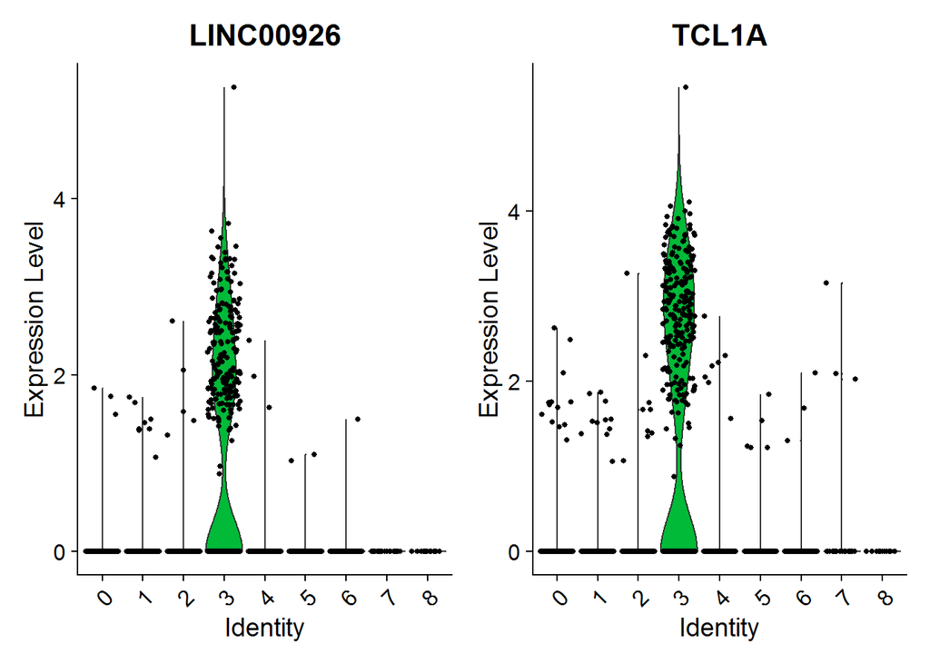

```r
cluster3.markers <- FindMarkers(pbmcdf, ident.1 = 3, logfc.threshold = 0.25, test.use = "roc", only.pos = TRUE)

VlnPlot(pbmcdf, features = c("LINC00926", "TCL1A"))
```

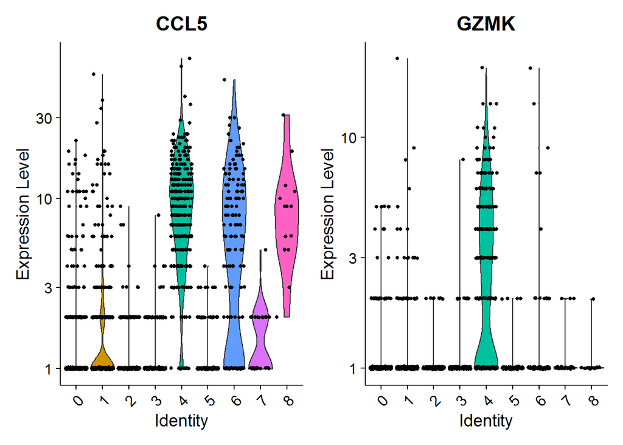

```r
# you can plot raw counts as well
VlnPlot(pbmcdf, features = c("CCL5", "GZMK"), slot = "counts", log = TRUE)
```

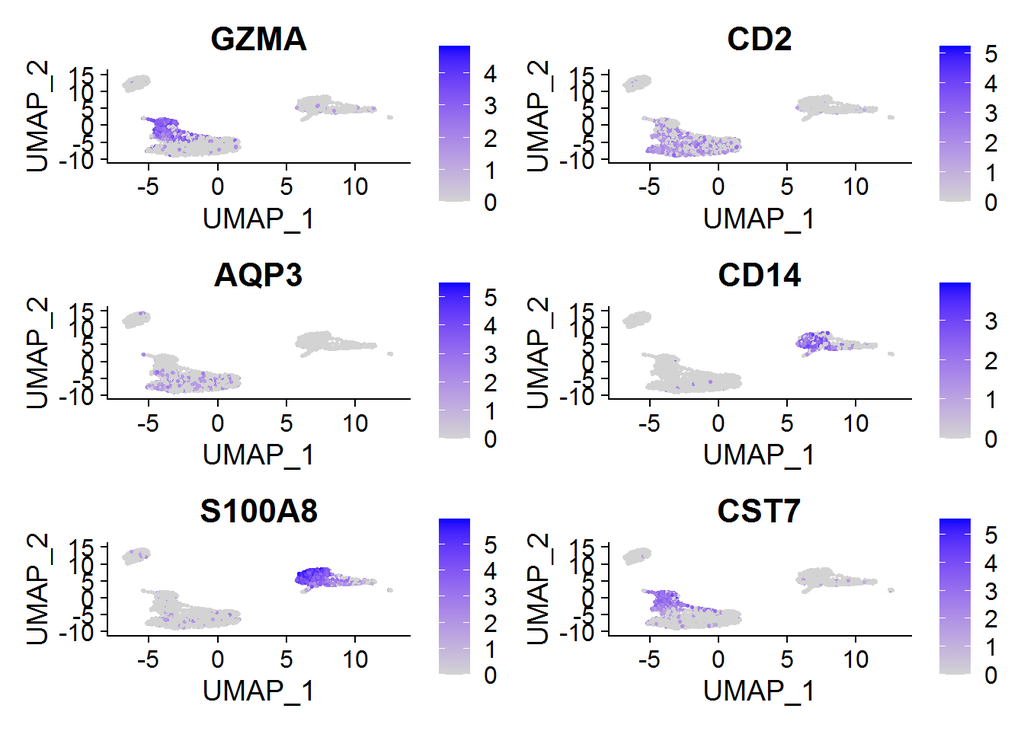

```r
FeaturePlot(pbmcdf, features = c("GZMA", "CD2", "AQP3", "CD14", "S100A8", "CST7"))
```

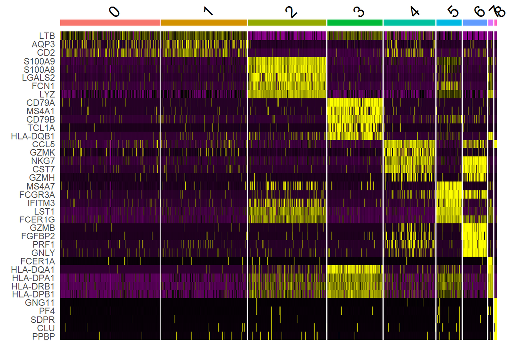

```r
top5 <- pbmcdf.markers %>% group_by(cluster) %>% top_n(n = 5, wt = avg_logFC)
DoHeatmap(pbmcdf, features = top5$gene) + NoLegend()
```

### Assigning cell type to clusters

Use canonical markers to match clustering to cell types

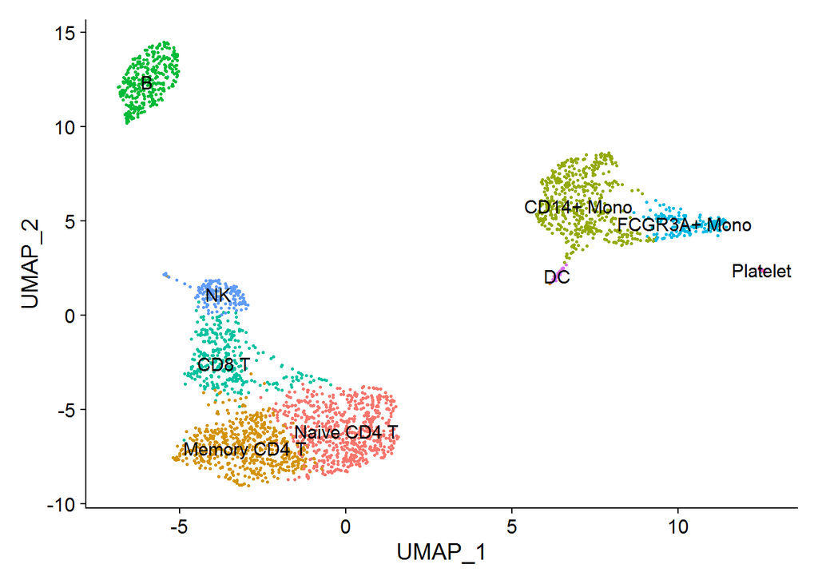

```r
new.cluster.ids <- c("Naive CD4 T", "Memory CD4 T", "CD14+ Mono", "B", "CD8 T", "FCGR3A+ Mono",
                     "NK", "DC", "Platelet")
names(new.cluster.ids) <- levels(pbmcdf)
pbmcdf <- RenameIdents(pbmcdf, new.cluster.ids)
DimPlot(pbmcdf, reduction = "umap", label = TRUE, pt.size = 0.5) + NoLegend()
```

```r
#saveRDS(pbmcdf, file = "output/pbmcdf3k_final.rds")
```